# Vertical_Profile

Flueckiger_Rubens

2025-05-27

In this file the vertical profiles of temperature and relative humidity gets calculated

*Note:* If a better visual performance of the graphic is needed, I recommend using the Julia script provided in the folder *Julia*. Dataset needed as well as the saved grafics are provided inside that folder.

# 1 Import packages, functions and files

```r
#Packages
library(ggplot2)
library(reshape2)

#Files
data <- read.table("../data/Distanz_&_Hohe_GR.csv", sep = ";", header = T)

#Functions
source("../Functions/cubic_parameters.R")
```

# 2 Colours

Set colour codes for the plots and the legend

# 3 Create new dataset

To improve runtime and visual aesthetics the initial 3894 data points of each sensor along the long route is reduced to 354 data points. This gets accomplished by taking an average over 11 consecutive data points.

# 3 Prepare plot

## 3.1 Cubic parameters

In a first step the function cubic parameters is applied to the temperature and relative air humidity values. Aim of this step is to calculate the cubic parameters a, b, c and d of the general cubic function (see below).
$$f(x) = ax^3 + bx^2 +
cx + d$$

Since extreme values over the whole sampling duration is concidered as well, the function *cubic_parameters* is applied over mean, maximum and minimum values for both temperature and humidity.

## 3.2 Curves

After calculating the parameters the curves are created. This step involves creating points in a small interval such that these points can be connected by a line further.

In a first step the quote on quote “normal” points are converted into a curve then the extreme values of both temperature and humidity. The latter is stored inside a seperate dataframe agian such that it can be accessed more easily at the plotting step.

# 4 Plots

Finally the plots can be created. Hereby we split the process into three steps.

## 4.1 Normal points

In this step the normal points are plotted. With a for loop every data point is plotted into a plot. Inside the plot the program checks if the current data point is located in a urban or a forest environment. If the data point is located in a urban environment, the curve is colered grey, else green.

## 4.2 Extremes

In a second step, all extreme values are plotted. This includes mean (in black), minimum and maximum (both in red).

## 4.3 Aesthetics and Save

In a final step, the plots are visually adjusted. This includes:

- Adding Axis label
- Adding title
- Adding Legend

Finally the plots are saved inside the *Images* folder

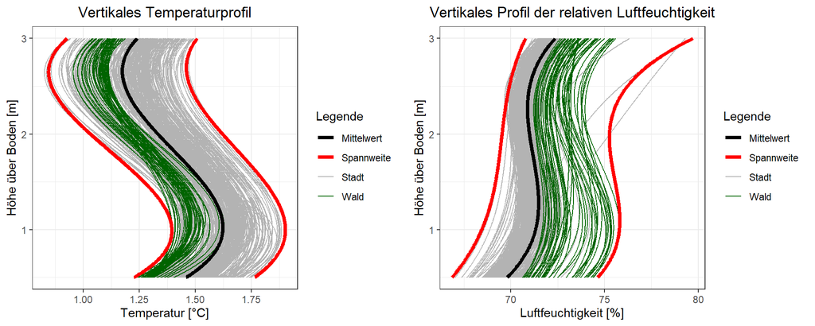

Fig. 1: Height profile of temperature (left) and humidity (right)

# 5 Statistics

In this step, a, b, c and d values of both temperature and humidity are displayed.

Kubische Parameter der mittleren Temperaturveränderung

| Grösse | a | b | c | d |
| --- | --- | --- | --- | --- |
| Temperatur | 0.20 | -1.13 | 1.66 | 0.89 |
| Luftfeuchtigkeit | 1.23 | -6.53 | 10.68 | 65.95 |

According to this table, following equation can be written for the mean temperature evolution:
$$\overline{T(h)}
= 0.2x^3 + -1.13x^2 + 1.66x + 0.89$$

And for the relative air humidity:

$$\overline{\varphi(h)} = 1.23x^3 +
-6.53x^2 + 10.68x + 65.95$$